# More practice with `ggplot2`

Data Science for Biologists, Spring 2020

KEY

2019-12-31

## Instructions

For this lab/assignment, you will continue to hone your plotting skills *and* learn how to read and use external datasets. Questions below are given as prompts with either templated or empty R chunks for you to fill in and complete.

You do **not** need to submit anything over Blackboard, but you **do** need to complete this entire document within RStudio Cloud by the hard deadline of **Thursday February 6th at 11:30 am**.

#### You will be graded on the following criteria:

- Did you enter your name appropriately into the YAML front matter?
- Does the document knit without errors? *Adding `eval=FALSE` to code chunks with errors will not avoid penalty.*
- Does your code have appropriate *comments*?
- Is your submission appropriately *professional*?
  - *You need to run SPELL CHECK before submitting*, available under `Edit->Check Spelling`.
- Do all figures have clean axis labels? (Titles are optional). There should NOT be any underscores in axis labels.
- Did you write your written answers in the answer style?
- Have you addressed the questions as they are asked? Be sure to limit your code and your answers to the scope of the question!
  - If you write code that is not ultimately part of your final answer, you must either: delete it, comment it out, OR move it to a different R chunk with the added chunk options `eval=FALSE, echo=FALSE`.
- Is all work your own, including code and written answers?
  - If ANY of your submitted work is not your own (with the exception of what you have been provided), you will receive a 0 on the assignment. You will be reported for a Level 2 or 3 Academic Integrity Violation, depending on the severity of the issue.

### Getting started

This assignment will make use of an *external data set*, i.e. a data set that you have to upload to R yourself. We will do this using the `readr` package, which is part of the core `tidyverse` and assists in reading/writing files. You will be working with a file called `"sparrows.csv"`. You will see this file is available already in this project in the Files pane in RStudio. If you click on this file name, it will appear in the Editor pane - this is a *comma-separated file* (CSV, comma-separated values), meaning each column of data is separated by a comma. Another way to say this is that the file is *comma-delimited*. It is also very common to see *tab-delimited* files (TSV) in data science.

Data in this file was collected in 1898 by Hermon Bumpus, an American biologist working at Brown University. Immediately following a bad winter storm, he collected 136 English house sparrows (some alive, some dead), *Passer domesticus*, and brought them indoors. Of these birds, 64 had died during the storm, but 72 recovered and survived. Bumpus measured the birds’ physical traits and recorded them for future generations of data science students.

#### Reading CSV files

We use the function `read_csv` from the package `readr` to read in CSV files. When using functions from specific packages, it is often safer to write them in the format `package::function()`, i.e. `readr::read_csv()`, just in case there is another function named `readr()` also floating around in the R environment. It is not likely this will happen to you at this stage of your data sciencing, but it doesn’t hurt to get in the habit.

We can read in the file as follows:

```r
## save the data frame, automatically made into a TIBBLE by readr
##    into the variable `sparrows`
sparrows <- read_csv("sparrows.csv")
## Examine the data
head(sparrows)
```

```
## # A tibble: 6 x 12
##   Sex   Age   Survival Length Wingspread Weight Skull_Length Humerus_Length
##   <chr> <chr> <chr>     <dbl>      <dbl>  <dbl>        <dbl>          <dbl>
## 1 Male  Adult Alive       154        241   24.5         31.2           17.4
## 2 Male  Adult Alive       160        252   26.9         30.8           18.7
## 3 Male  Adult Alive       155        243   26.9         30.6           18.6
## 4 Male  Adult Alive       154        245   24.3         31.7           18.8
## 5 Male  Adult Alive       156        247   24.1         31.5           18.2
## 6 Male  Adult Alive       161        253   26.5         31.8           19.8
## # … with 4 more variables: Femur_Length <dbl>, Tarsus_Length <dbl>,
## #   Sternum_Length <dbl>, Skull_Width <dbl>
```

#### Understanding factors

Part of this lab/assignment will necessitate working with *factors*, a special type of variable used to work with categories of categorical variables. By default, `readr` assumes that NOTHING is a factor, so we have the full power to determine which variables are factors, and what the *order* of the categories should be. In R, we call the categories of a factor its *levels*.

> The base R version of the `read_csv` function is `read.csv` and assumes any character is a factor - this problem notoriously causes everyone a lot of major headaches. `readr` rescued us all with its lovely `read_csv` alternative.

The `tidyverse` package [`forcats`](https://forcats.tidyverse.org/) has rich functionality for working with and modifying factors, but for now these features are a bit too advanced (although have at it if you want!), so we will use some convenient base R code.

From the `head(sparrows)` output, we see at least three columns are designed `<chr>`, meaning R thinks those columns are characters - plain old works with nothing interesting linking them. But, we know “better” - it is clear that columns `Sex`, `Age`, and `Survival` are categorical variables with distinct categories (levels!). We can convert these columns to factors like this:

```r
### Convert Sex to a factor
sparrows$Sex <- factor(sparrows$Sex)

### If we run head() again, we'll see it's a factor now
head(sparrows)
```

```
## # A tibble: 6 x 12
##   Sex   Age   Survival Length Wingspread Weight Skull_Length Humerus_Length
##   <fct> <chr> <chr>     <dbl>      <dbl>  <dbl>        <dbl>          <dbl>
## 1 Male  Adult Alive       154        241   24.5         31.2           17.4
## 2 Male  Adult Alive       160        252   26.9         30.8           18.7
## 3 Male  Adult Alive       155        243   26.9         30.6           18.6
## 4 Male  Adult Alive       154        245   24.3         31.7           18.8
## 5 Male  Adult Alive       156        247   24.1         31.5           18.2
## 6 Male  Adult Alive       161        253   26.5         31.8           19.8
## # … with 4 more variables: Femur_Length <dbl>, Tarsus_Length <dbl>,
## #   Sternum_Length <dbl>, Skull_Width <dbl>
```

```r
### Once converted, let's see its levels
levels(sparrows$Sex)
```

```
## [1] "Female" "Male"
```

R has decided that “Female” should be ordered before “Male” because of alphabetical order. If we had a compelling reason for “Male” to be first (this comes into play mostly for plotting reasons, and as we will learn in a few months, data modeling), we can specify the order of levels directly:

```r
### Make the order Male, Female. This can reorder levels, but the names of levels CANNOT CHANGE (for now..)!
levels(sparrows$Sex) <- c("Male", "Female")

## Print it out to see
print(levels(sparrows$Sex))
```

```
## [1] "Male"   "Female"
```

This can also all be done at once with the single command below.

```r
### All at once
sparrows$Sex <- factor(sparrows$Sex, levels=c("Male", "Female"))
```

## Questions

##### Question 1

Convert the columns `Survival` and `Age` into factors. For `Survival`, the order should be (1) Alive, (2) Dead. for `Age`, the order should be (1) Young, (2) Adult.

- In total, this should be *two* lines of code only (one line for each variable) - in a single line, you should set the variable as a factor AND define its levels.
- Confirm you are correct by printing the LEVELS of each column

```r
## Fill in your code here
sparrows$Survival <- factor(sparrows$Survival, levels=c("Alive", "Dead"))
sparrows$Age <- factor(sparrows$Age, levels=c("Young", "Adult"))

levels(sparrows$Survival)
```

```
## [1] "Alive" "Dead"
```

```r
levels(sparrows$Age)
```

```
## [1] "Young" "Adult"
```

##### Question 2

Visualize the distribution of `Survival` using a bar plot, where all bars are filled with a single color of your choosing.

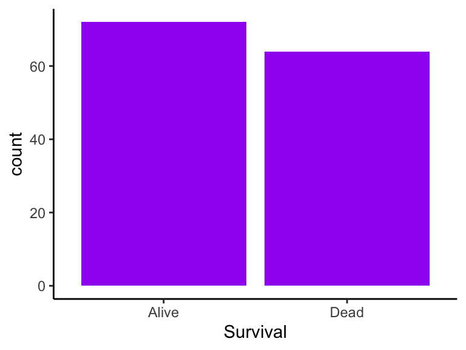

```r
### Barplot code goes here
ggplot(sparrows, aes(x = Survival)) + geom_bar(fill = "purple")
```

##### Question 3

Visualize the distribution of `Survival` using a bar plot, where bars are also colored (filled) by `Age`, to make a *grouped bar plot*. There are two ways these bars can be represented: stacked (this will happen by DEFAULT when you add the fill) or dodged (add the argument `position = "dodge"` to `geom_bar()`).

- When making these plots, you should SAVE your `ggplot` object to a variable and then PRINT the variable in the R chunk, e.g.:

  ```r
  p1 <- ggplot(sparrows, aes(...)) + geom_whatever()
  print(p1)
  ```

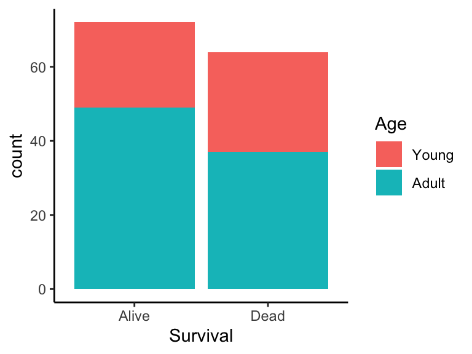

```r
## Fill in your code here for the STACKED barplot.
p1 <- ggplot(sparrows, aes(x = Survival)) + geom_bar(aes(fill = Age))
print(p1)
```

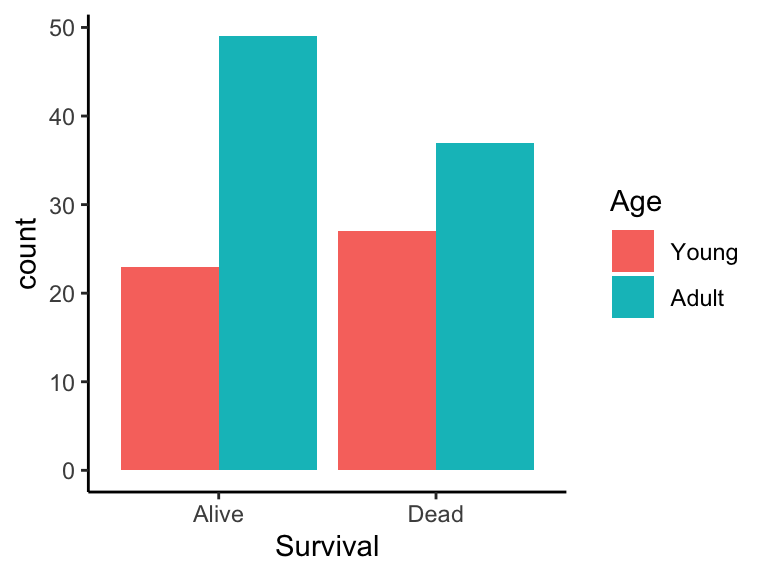

```r
## Fill in your code here for the DODGED barplot.
p2 <- ggplot(sparrows, aes(x = Survival)) + geom_bar(aes(fill = Age), position = "dodge")
print(p2)
```

##### Question 4

It is possible to add plots together with the *awesome* package [`patchwork`](https://patchwork.data-imaginist.com/articles/patchwork.html), which has been installed and loaded for you. Below, add your two bar plots together with a `+` sign by adding the two variables - the code will be short! Then, stack your plots by dividing with with the `/` sign. *You will need to tweak the figure width/height to get a nice-looking output, beware.*

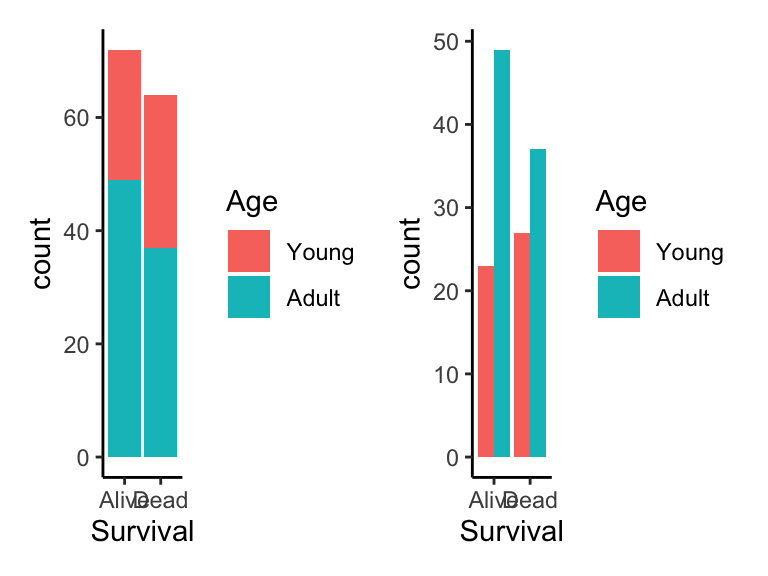

```r
## Add the plots for side-by-side view
p1 + p2
```

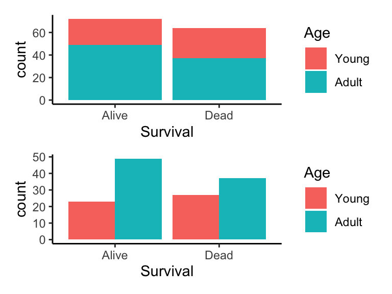

```r
## Divide the plots for a stacked view
p1/p2
```

##### Question 5

Compare the distributions of living vs. dead sparrow skull widths using a single *density plot*, where distributions are colored (filled) according to their `Survival` status. Make sure both distributions are fully visible and not blocking each other (hint! what other option do you need?), and specify *your own* colors for this task using either colors of your choosing or an existing palette.

In the space below, write 1-2 sentences about whether skull width may have been a contributing factor to who lived and who died.

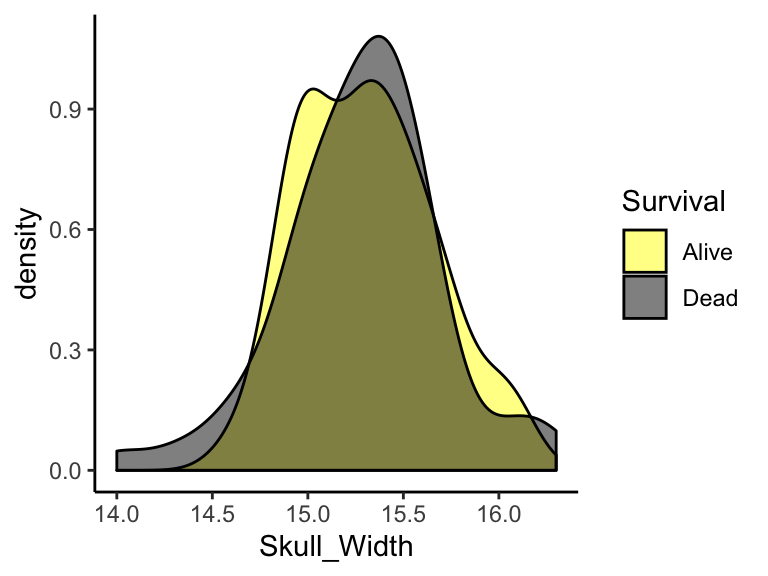

```r
## Fill in your density plot code here
ggplot(sparrows, aes(x = Skull_Width, fill = Survival)) +
  geom_density(alpha = 0.5) +
  scale_fill_manual(values=c("yellow", "black"))
```

##### Question 6

We will now learn to make a *faceted* plot, which splits your figure into a row or grid of panels highlighting different subsets of the data. Our goal is to re-make the density plot from Question 5, but *faceting by sex*: This means there will be one plot for Males and one plot for Females (ordered by factor level!!). There are two functions that can accomplish this: `facet_wrap()` and `facet_grid()`; the latter is most useful for faceting multiple variables.

- Consider this simple example of visualizing iris sepal lengths *faceted by Species*, using the function `facet_wrap()`:

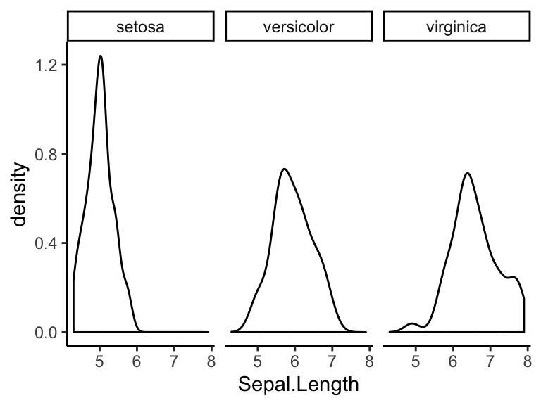

  ```r
  ggplot(iris, aes(x = Sepal.Length)) +
    geom_density() +
    facet_wrap(~Species) ## the tilde!! so important!!
  ```

Now, convert your plot from Question 5 so that it is faceted by `Sex`. In the space below, write 2-4 sentences about whether considering sex separately when plotting helped you to understand trends in the data. What trends do you now see that you didn’t see before, if any? What trends are new?

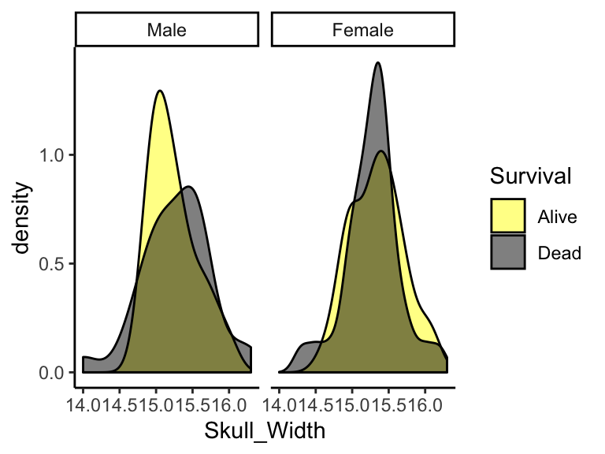

```r
### code for faceted plot goes here
ggplot(sparrows, aes(x = Skull_Width, fill = Survival)) +
  geom_density(alpha = 0.5) +
  scale_fill_manual(values=c("yellow", "black")) +
  facet_wrap(~Sex)
```

##### Question 7

Make a jitter plot of `Weight` across `Sex`, colored by `Age`. *Before you plot, think carefully about what belongs on X vs Y axis.* For this task, you should choose your own colors, ensure the jitter width makes the plot readable, AND place the legend at the BOTTOM of the plot.

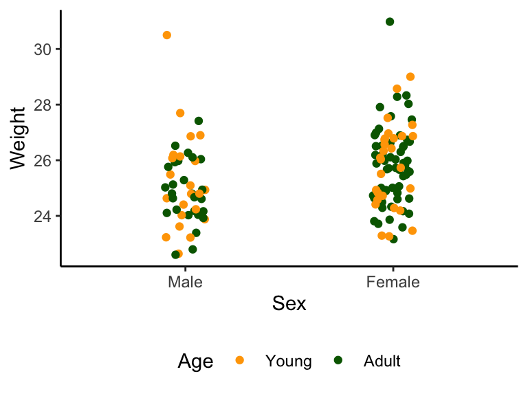

```r
ggplot(sparrows, aes(x = Sex, y = Weight, color = Age)) +
  geom_jitter(width = 0.1) +
  scale_color_manual(values = c("orange", "darkgreen")) +
  theme(legend.position = "bottom")
```